# Logistic Regression for Loansharks (2014 Pennsylvania)

# Model with census data integrated.

```r
# https://www2.census.gov/programs-surveys/popest/datasets/2010-2018/counties/asrh/
census_pa_file_path <- paste(census_data_dir, sep = "", "/cc-est2018-alldata-42.csv")

merged_hmda_data_df_for_model <- merge_hmda_df_with_census(census_pa_file_path, hmda_data_df_for_model)

split_dfs <- train_test_split(merged_hmda_data_df_for_model$loan_granted, merged_hmda_data_df_for_model)

merged_train <- split_dfs[[1]]
merged_test <- split_dfs[[2]]

merged_2014_model <- build_glm_model("loan_granted~applicant_race_and_ethnicity+owner_occupancy+preapproval+property_type+log_loan_amount_000s+tract_to_msamd_income+co_applicant_present+agency_code+BLACK_PERCENT+ASIAN_PERCENT+HISPANIC_PERCENT+county_code+respondent_id+applicant_sex+loan_purpose+loan_to_income_ratio", merged_train)
```

```
glm.fit: fitted probabilities numerically 0 or 1 occurred
```

```r
model5_fitted.probs <- predict(merged_2014_model, merged_test, type = "response")

writeLines("")
```

```r
writeLines("Merged model performance")
```

```
Merged model performance
```

```
[1] "no"  "yes"
[1] "Accuracy 0.740949143270226"
Confusion Matrix and Statistics

          Reference
Prediction    no   yes
       no   7704  5609
       yes  7650 30220

               Accuracy : 0.7409
                 95% CI : (0.7371, 0.7447)
    No Information Rate : 0.7
    P-Value [Acc > NIR] : < 0.00000000000000022

                  Kappa : 0.3588

 Mcnemar's Test P-Value : < 0.00000000000000022

            Sensitivity : 0.8435
            Specificity : 0.5018
         Pos Pred Value : 0.7980
         Neg Pred Value : 0.5787
             Prevalence : 0.7000
         Detection Rate : 0.5904
   Detection Prevalence : 0.7399
      Balanced Accuracy : 0.6726

       'Positive' Class : yes

Confusion Matrix and Statistics

          Reference
Prediction    no   yes
       no   7704  5609
       yes  7650 30220

               Accuracy : 0.7409
                 95% CI : (0.7371, 0.7447)
    No Information Rate : 0.7
    P-Value [Acc > NIR] : < 0.00000000000000022
```

[output cut: 11 more lines]

```
   Detection Prevalence : 0.7399
      Balanced Accuracy : 0.6726

       'Positive' Class : yes

[1] "Precision not found"
[1] "Prevalence"
[1] "Precision and Recall"
[1] 0.7979931
[1] 0.8434508
[[1]]
[1] 0.7979931

[[2]]
[1] 0.8434508
```

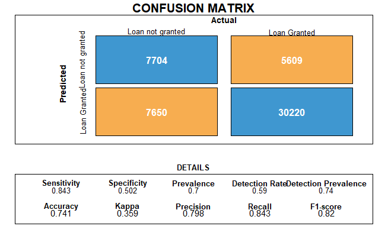

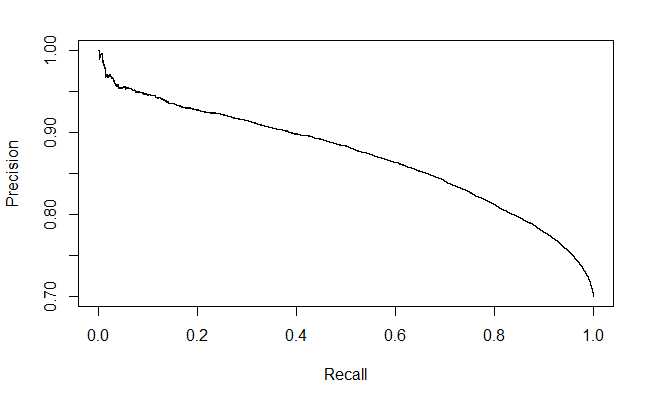

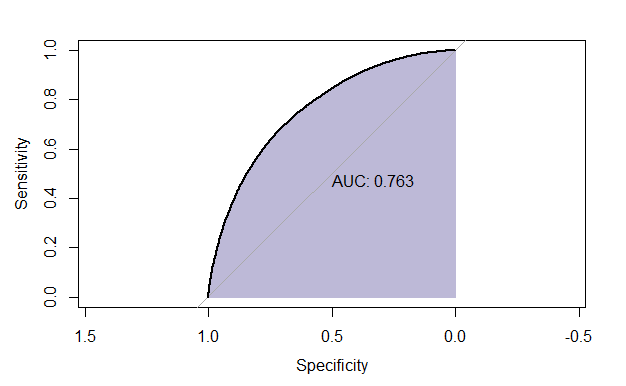

```r
print_model_performance(model5_fitted.probs, merged_test, positive = "yes", negative = "no", threshold = 0.6)
```

# Loan to value ratio is an important metric which banks use to decide

# whether a loan should be granted or not. For e.g. the higher the loan

# to value ratio the riskier it is for the bank.

# https://en.wikipedia.org/wiki/Loan-to-value_ratio

# Banks are not required to report this metric in the HMDA reporting

# law. We use the median of the home values in that county based on

# data available from zillow https://www.zillow.com/research/data/

```r
period_list <- c("2014-01", "2014-02", "2014-03", "2014-04",
                 "2014-05", "2014-06", "2014-07", "2014-08",
                 "2014-09", "2014-10", "2014-11", "2014-12")

merged_hmda_with_loan_to_value_ratio <- augment_hmda_data_with_estimated_loan_to_value_ratio_from_zillow(paste(data_dir, "/zillow/counties_home_value_per_year.csv", sep = ""), hmda_data_df_for_model, "PA", period_list)
```

```
 [1] "2014-01"    "2014-02"    "2014-03"    "2014-04"    "2014-05"
 [6] "2014-06"    "2014-07"    "2014-08"    "2014-09"    "2014-10"
[11] "2014-11"    "2014-12"    "RegionName"
```

```r
head(merged_hmda_with_loan_to_value_ratio)
```

|  | county_name | applicant_race_and_ethnicity | applicant_income_000s | co_applicant_race_and_ethnicity | co_applicant_sex | hoepa_status | lien_status | msamd | owner_occupancy | preapproval | purchaser_type | property_type | loan_amount_000s | applicant_sex | hud_median_family_income | tract_to_msamd_income | loan_to_income_ratio | agency_code | minority_population | loan_purpose | rate_spread | population | number_of_owner_occupied_units | loan_granted | log_loan_amount_000s | log_applicant_income_000s | credit_score | co_applicant_present | respondent_id | … |
| --- | --- | --- | --- | --- | --- | --- | --- | --- | --- | --- | --- | --- | --- | --- | --- | --- | --- | --- | --- | --- | --- | --- | --- | --- | --- | --- | --- | --- | --- | --- |
| 1 | Adams County | White | 36 | No co-applicant | 5 | 2 | 1 | 23900 | 1 | 2 | 1 | 1 | 124 | 1 | 64100 | 177.68 | 3.4444444 | 9 | 11.43 | 1 | 1.83 | 3315 | 212 | yes | 4.820282 | 3.583519 | 734 | 0 | 0000501105 | … |
| 2 | Adams County | No Information Provided | 148 | No co-applicant | 5 | 2 | 1 | 23900 | 1 | 2 | 3 | 1 | 135 | 3 | 64100 | 120.84 | 0.9121622 | 7 | 5.19 | 1 | 1.61 | 3179 | 1035 | yes | 4.905275 | 4.997212 | 732 | 0 | 7197000003 | … |
| 3 | Adams County | White | 49 | White | 2 | 2 | 1 | 44300 | 1 | 3 | 0 | 2 | 29 | 1 | 78300 | 48.23 | 0.5918367 | 7 | 61.74 | 1 | 2.87 | 3152 | 390 | no | 3.367296 | 3.891820 | 734 | 1 | 7162800002 | … |
| 4 | Adams County | White | 42 | White | 2 | 2 | 1 | 23900 | 1 | 3 | 0 | 1 | 202 | 1 | 64100 | 81.73 | 4.8095238 | 7 | 16.48 | 3 | 2.02 | 4156 | 1097 | no | 5.308268 | 3.737670 | 734 | 1 | 41-1795868 | … |
| 5 | Adams County | No Information Provided | 152 | Information not provided by applicant in mail, Internet, or telephone application | 3 | 2 | 1 | 23900 | 1 | 3 | 0 | 1 | 252 | 3 | 64100 | 116.84 | 1.6578947 | 7 | 4.11 | 3 | 2.36 | 6887 | 2253 | no | 5.529429 | 5.023881 | 732 | 0 | 7197000003 | … |
| 6 | Adams County | White | 70 | White | 2 | 2 | 1 | 23900 | 1 | 3 | 0 | 1 | 291 | 1 | 64100 | 87.98 | 4.1571429 | 2 | 15.82 | 3 | 2.24 | 5500 | 1677 | no | 5.673323 | 4.248495 | 734 | 1 | other | … |

```r
NA
```

# Train test split on the hmda dataset merged with estimated loan to value

# ratio

```r
split_dfs <- train_test_split(merged_hmda_with_loan_to_value_ratio$loan_granted, merged_hmda_with_loan_to_value_ratio)
new_train <- split_dfs[[1]]
new_test <- split_dfs[[2]]
```

## Model with estimated loan to value ratio.

```r
model_2014_with_loan_to_value_ratio <-
build_glm_model("loan_granted~applicant_race_and_ethnicity+owner_occupancy+preapproval+log_loan_amount_000s+applicant_sex+county_code+tract_to_msamd_income+co_applicant_present+agency_code+minority_population+loan_to_income_ratio+loan_purpose+rate_spread+property_type+loan_to_value_ratio+respondent_id", new_train)
```

```
glm.fit: fitted probabilities numerically 0 or 1 occurred
```

```
Model summary


Call:
glm(formula = as.formula(model_formula), family = binomial(link = "logit"),
    data = train_df, control = glm.control(maxit = iter))

Deviance Residuals:
    Min       1Q   Median       3Q      Max
-2.9920  -0.8775   0.5208   0.7983   8.4904

Coefficients:
                                                                        Estimate
(Intercept)                                                           -0.0821117
applicant_race_and_ethnicityAsian                                      0.4681513
applicant_race_and_ethnicityBlack or African American                  0.1746241
applicant_race_and_ethnicityHispanic or Latino                         0.1980085
applicant_race_and_ethnicityNative Hawaiian or Other Pacific Islander  0.1498805
applicant_race_and_ethnicityNo Information Provided                    0.3665703
applicant_race_and_ethnicityNot applicable                            -0.1422798
applicant_race_and_ethnicityWhite                                      0.7271200
owner_occupancy2                                                      -0.1228370
owner_occupancy3                                                      -0.0770529
preapproval2                                                          -0.2853014
preapproval3                                                          -0.3173947
log_loan_amount_000s                                                   0.0993533
applicant_sex2                                                        -0.0434562
applicant_sex3                                                        -0.0889469
applicant_sex4                                                         1.8532272
county_code11                                                         -0.0352024
county_code125                                                         0.1038410
county_code129                                                         0.1087373
county_code133                                                         0.0365517
county_code17                                                          0.0915478
county_code19                                                          0.3320896
county_code27                                                          0.2270035
county_code29                                                          0.1675338
county_code3                                                           0.1551980
county_code41                                                          0.1948065
county_code43                                                          0.1173728
```

[output cut: 504 more lines]

```
respondent_id7734800004                                               ***
respondent_id7774500004                                               ***
respondent_idother                                                    ***
---
Signif. codes:  0 ‘***’ 0.001 ‘**’ 0.01 ‘*’ 0.05 ‘.’ 0.1 ‘ ’ 1

(Dispersion parameter for binomial family taken to be 1)

    Null deviance: 250125  on 204734  degrees of freedom
Residual deviance: 210518  on 204629  degrees of freedom
AIC: 210730

Number of Fisher Scoring iterations: 6

Anova for model
```

[output not shown]

```
Analysis of Deviance Table

Model: binomial, link: logit

Response: loan_granted

Terms added sequentially (first to last)

                             Df Deviance Resid. Df Resid. Dev
NULL                                        204734     250125
applicant_race_and_ethnicity  7   7896.0    204727     242229
owner_occupancy               2     33.0    204725     242196
preapproval                   2   4139.7    204723     238056
log_loan_amount_000s          1   3571.6    204722     234484
applicant_sex                 3    210.0    204719     234274
county_code                  25    970.3    204694     233304
tract_to_msamd_income         1    751.4    204693     232553
co_applicant_present          1    909.5    204692     231643
agency_code                   5   3730.3    204687     227913
minority_population           1    118.3    204686     227795
loan_to_income_ratio          1   1073.7    204685     226721
loan_purpose                  2   6082.7    204683     220638
rate_spread                   1    466.7    204682     220171
property_type                 2   1091.4    204680     219080
loan_to_value_ratio           1     82.9    204679     218997
respondent_id                50   8478.8    204629     210518
                                          Pr(>Chi)
NULL
applicant_race_and_ethnicity < 0.00000000000000022 ***
owner_occupancy                      0.00000006886 ***
preapproval                  < 0.00000000000000022 ***
log_loan_amount_000s         < 0.00000000000000022 ***
applicant_sex                < 0.00000000000000022 ***
county_code                  < 0.00000000000000022 ***
tract_to_msamd_income        < 0.00000000000000022 ***
co_applicant_present         < 0.00000000000000022 ***
agency_code                  < 0.00000000000000022 ***
minority_population          < 0.00000000000000022 ***
loan_to_income_ratio         < 0.00000000000000022 ***
loan_purpose                 < 0.00000000000000022 ***
rate_spread                  < 0.00000000000000022 ***
property_type                < 0.00000000000000022 ***
loan_to_value_ratio          < 0.00000000000000022 ***
respondent_id                < 0.00000000000000022 ***
---
Signif. codes:  0 ‘***’ 0.001 ‘**’ 0.01 ‘*’ 0.05 ‘.’ 0.1 ‘ ’ 1
```

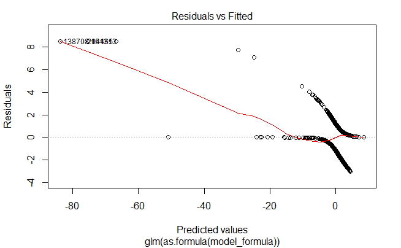

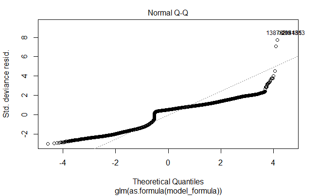

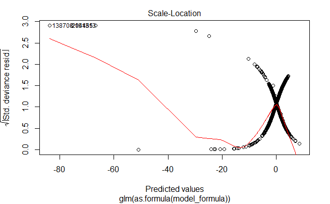

```
optimal cut threshold is
                 [,1]
sensitivity 0.6960675
specificity 0.6923979
cutoff      0.7002658
```

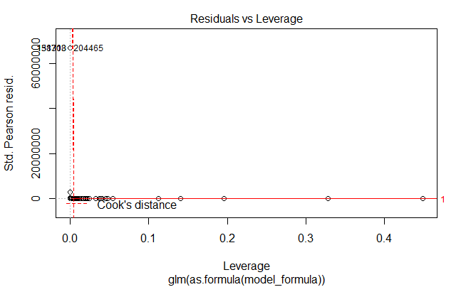

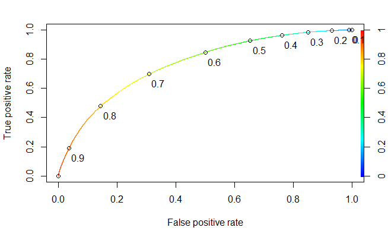

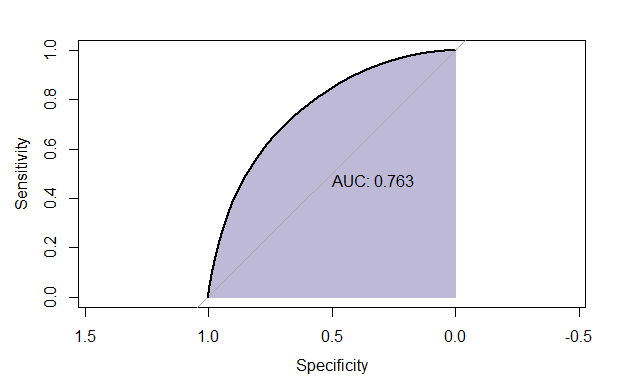

```r
model_summary_and_plot(model_2014_with_loan_to_value_ratio, train = new_train)
```

```r
mcfadden_r_square(model_2014_with_loan_to_value_ratio, null_model)
```

```
Mcfadden Rsquare value
'log Lik.' 0.1598621 (df=106)
```

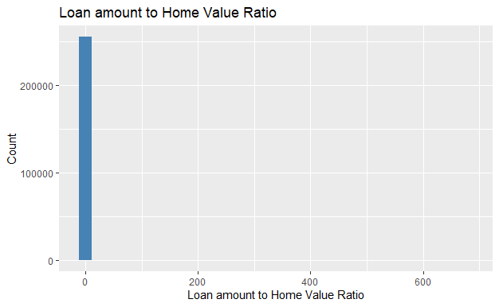

```r
ggplot(data = merged_hmda_with_loan_to_value_ratio, aes(x=loan_to_value_ratio)) +geom_histogram(fill = "steelblue") + labs(title = "Loan amount to Home Value Ratio" , x = "Loan amount to Home Value Ratio",y="Count")
```

```r
model6_fitted.probs <- predict(model_2014_with_loan_to_value_ratio, new_test, type = "response")

writeLines("")
```

```r
writeLines("Model with estimated loan to value ratio performance")
```

```
Model with estimated loan to value ratio performance
```

```
[1] "no"  "yes"
[1] "Accuracy 0.742238633921419"
Confusion Matrix and Statistics

          Reference
Prediction    no   yes
       no   7617  5456
       yes  7737 30373

               Accuracy : 0.7422
                 95% CI : (0.7384, 0.746)
    No Information Rate : 0.7
    P-Value [Acc > NIR] : < 0.00000000000000022

                  Kappa : 0.3591

 Mcnemar's Test P-Value : < 0.00000000000000022

            Sensitivity : 0.8477
            Specificity : 0.4961
         Pos Pred Value : 0.7970
         Neg Pred Value : 0.5827
             Prevalence : 0.7000
         Detection Rate : 0.5934
   Detection Prevalence : 0.7446
      Balanced Accuracy : 0.6719

       'Positive' Class : yes

Confusion Matrix and Statistics

          Reference
Prediction    no   yes
       no   7617  5456
       yes  7737 30373

               Accuracy : 0.7422
                 95% CI : (0.7384, 0.746)
    No Information Rate : 0.7
    P-Value [Acc > NIR] : < 0.00000000000000022
```

[output cut: 11 more lines]

```
   Detection Prevalence : 0.7446
      Balanced Accuracy : 0.6719

       'Positive' Class : yes

[1] "Precision not found"
[1] "Prevalence"
[1] "Precision and Recall"
[1] 0.7969824
[1] 0.8477211
[[1]]
[1] 0.7969824

[[2]]
[1] 0.8477211
```

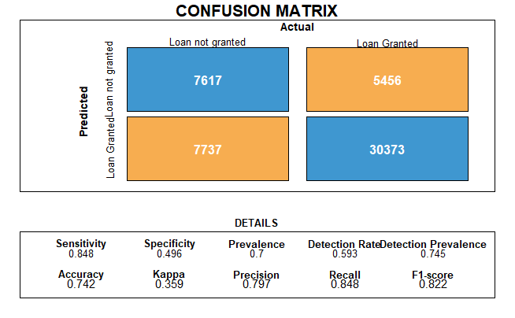

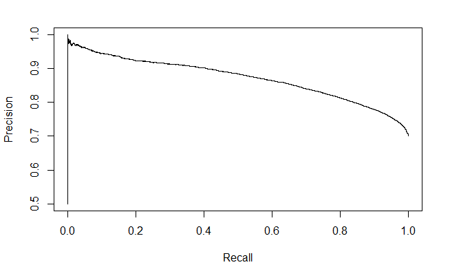

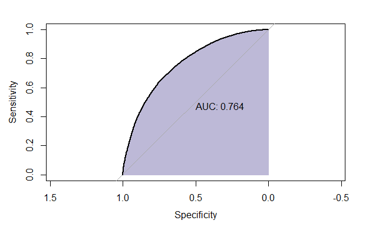

```r
print_model_performance(model6_fitted.probs, new_test, positive = "yes", negative = "no", threshold = 0.6)
```

# Save the models

```r
dir.create(model_path, showWarnings = FALSE)
save(model_2014_income_loan_amount, file = paste(model_path, "/model_income_loan_amount.rdata", sep=""))
save(model_2014_log_income_loan_amount, file = paste(model_path, "/model_log_income_loan_amount.rdata", sep=""))
save(model_2014_ratio_of_loan_to_income_with_log_of_income_and_amount, file = paste(model_path, "/model_loan_income_ratio_with_log_of_income_and_amount.rdata", sep=""))
save(model_2014_cross_val_loan_income_ratio, file = paste(model_path, "/cross_val_model.rdata", sep=""))
save(merged_2014_model, file = paste(model_path, "/merged_model.rdata", sep=""))

save(model_2014_with_loan_to_value_ratio, file = paste(model_path, "/merged_model_with_loan_to_value.rdata", sep=""))
```

# Save the train and test data for future reference.

```r
dir.create(model_data_path, showWarnings = FALSE)
save(train, file = paste(model_data_path, "/train.rdata", sep = ""))
save(test, file = paste(model_data_path, "/test.rdata", sep = ""))

dir.create(model_data_path, showWarnings = FALSE)
save(merged_train, file = paste(model_data_path, "/merged_train.rdata", sep = ""))
save(merged_test, file = paste(model_data_path, "/merged_test.rdata", sep = ""))

dir.create(model_data_path, showWarnings = FALSE)
save(new_train, file = paste(model_data_path, "/train_with_loan_to_value.rdata", sep = ""))
save(new_test, file = paste(model_data_path, "/test_with_loan_to_value.rdata", sep = ""))
```